# Clustering and PCA Analysis

Ornella and Ozgur’s project

An analysis of Medicare take-up and a Singular value decomposition exercise

Ornella Darova , Ozgur Seker true  
2021-05-05

# Clustering

## Medicare

We perform a clustering exercise at the state level, focusing on the take-up of the Medicare program.

```r
library(cluster)
library(factoextra)

# Consider eligible individuals for medicare
ncps_el = subset(ncps, ncps$med_elig==1)
ncps_sub = select(ncps_el,c("famincAssigned","pub","medicare","male","black",
               "married","foreign","veteran","nchildren","unemployed",
               "phone","is_largefmly","health","statefip"))
ncps_sub[c("famincAssigned","pub","medicare","male","black",
               "married","foreign","veteran","nchildren","unemployed",
               "phone","is_largefmly","health")] = ncps_sub[c("famincAssigned","pub","medicare","male","black",
               "married","foreign","veteran","nchildren","unemployed",
               "phone","is_largefmly","health")] %>% mutate_all(as.numeric)
```

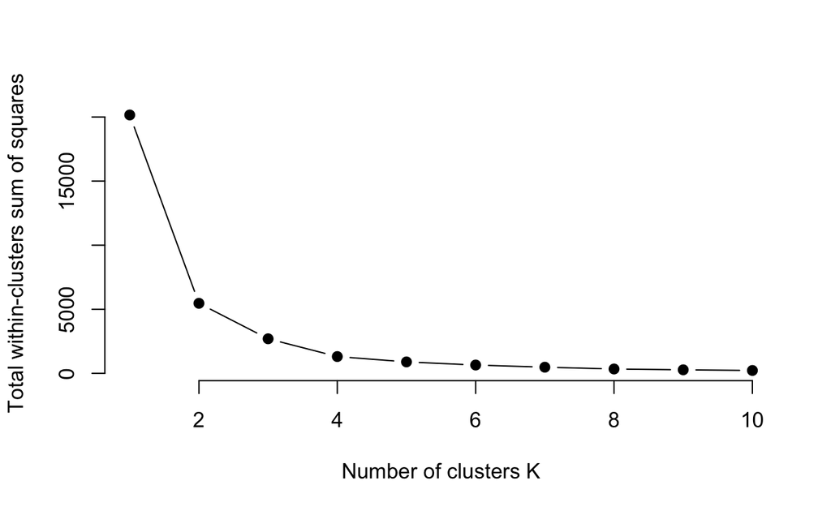

```r
# Consider first those who actually take up the program
take_up = subset(ncps_sub,medicare==1)
take_up = take_up[c("famincAssigned","pub","male","black",
               "married","foreign","veteran","nchildren","unemployed",
               "phone","is_largefmly","health","statefip")]

# Aggregate at the state level
ncps_statefip <- aggregate(take_up, by=list(take_up$statefip), FUN=mean, na.rm = TRUE)
ncps_statefip$famincAssigned <- scale(ncps_statefip$famincAssigned)

## Elbow method to find optimal number of clusters
set.seed(123)

# Function to compute total within-cluster sum of square
wss <- function(k) {
  kmeans(na.omit(ncps_statefip), k, nstart = 10 )$tot.withinss
}

# Compute wss
k.values <- 1:10

# Extract wss for different numbers of clusters
library(purrr)
wss_values <- purrr::map_dbl(k.values, wss)

plot(k.values, wss_values,
       type="b", pch = 19, frame = FALSE,
       xlab="Number of clusters K",
       ylab="Total within-clusters sum of squares")
```

```r
## 4 clusters seems to be sufficient
# Clustering

rownames(ncps_statefip) = ncps_statefip$statefip

ncps_statefip = select(ncps_statefip,c("famincAssigned","pub","male","black",
               "married","foreign","veteran","nchildren","unemployed",
               "phone","is_largefmly","health"))
k2 <- kmeans(na.omit(ncps_statefip), centers = 4, nstart = 25)
str(k2)
```

```
List of 9
 $ cluster     : Named int [1:45] 4 2 4 3 3 1 2 1 4 2 ...
  ..- attr(*, "names")= chr [1:45] "1" "4" "5" "6" ...
 $ centers     : num [1:4, 1:12] 1.693 -0.214 0.572 -1.009 0.214 ...
  ..- attr(*, "dimnames")=List of 2
  .. ..$ : chr [1:4] "1" "2" "3" "4"
  .. ..$ : chr [1:12] "famincAssigned" "pub" "male" "black" ...
 $ totss       : num 47.5
 $ withinss    : num [1:4] 2.071 1.199 0.764 2.643
 $ tot.withinss: num 6.68
 $ betweenss   : num 40.8
 $ size        : int [1:4] 8 16 7 14
 $ iter        : int 2
 $ ifault      : int 0
 - attr(*, "class")= chr "kmeans"
```

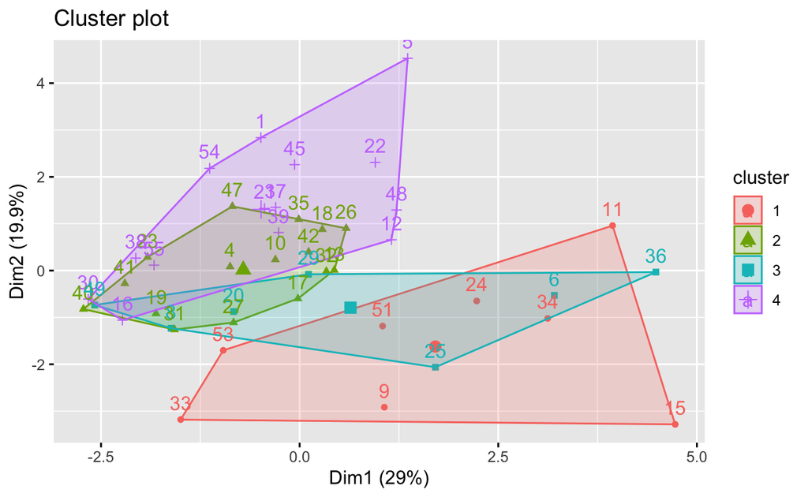

```r
fviz_cluster(k2, data = na.omit(ncps_statefip))
```

```r
na.omit(ncps_statefip) %>%
  mutate(Cluster = k2$cluster) %>%
  group_by(Cluster) %>%
  summarise_all("mean")
```

```
# A tibble: 4 x 13
  Cluster famincAssigned   pub  male black married foreign veteran
    <int>          <dbl> <dbl> <dbl> <dbl>   <dbl>   <dbl>   <dbl>
1       1          1.69  0.214 0.433 0.230   0.507   0.246   0.196
2       2         -0.214 0.140 0.443 0.117   0.554   0.130   0.221
3       3          0.572 0.142 0.436 0.109   0.542   0.249   0.182
4       4         -1.01  0.164 0.438 0.169   0.515   0.103   0.214
# … with 5 more variables: nchildren <dbl>, unemployed <dbl>,
#   phone <dbl>, is_largefmly <dbl>, health <dbl>
```

```r
na.omit(ncps_statefip) %>%
  mutate(Cluster = k2$cluster) %>%
  group_by(Cluster)
```

```
# A tibble: 45 x 13
# Groups:   Cluster [4]
   famincAssigned[,1]    pub  male  black married foreign veteran
                <dbl>  <dbl> <dbl>  <dbl>   <dbl>   <dbl>   <dbl>
 1             -1.17  0.0606 0.439 0.350    0.564  0.0202   0.204
 2             -0.107 0.0872 0.464 0.0431   0.576  0.225    0.218
 3             -1.97  0.172  0.412 0.339    0.396  0.0395   0.236
 4              0.670 0.139  0.442 0.0948   0.526  0.465    0.164
 5              0.714 0.126  0.452 0.0477   0.552  0.123    0.233
 6              2.09  0.256  0.453 0.134    0.494  0.253    0.176
 7             -0.190 0.226  0.437 0.211    0.554  0.116    0.221
 8              1.29  0.286  0.394 0.751    0.309  0.135    0.156
 9             -0.789 0.152  0.443 0.128    0.535  0.418    0.184
10             -0.169 0.165  0.436 0.286    0.624  0.183    0.179
# … with 35 more rows, and 6 more variables: nchildren <dbl>,
#   unemployed <dbl>, phone <dbl>, is_largefmly <dbl>, health <dbl>,
#   Cluster <int>
```

The formed clusters are the following:

1. Connecticut, District of Columbia, Hawaii, Marayland, New Hampshire, New Jersey, Virginia, Washington
2. Arizona, Delaware, Georgia, Illinoi, Indiana, Iowa, Maine, Michigan, Minnesota, Nebraska, Nevada, New Mexico, Oklahoma, Oregon, Pennsylvania, Tennessee
3. California, Colorado, Kansas, Massachussetts, Missouri, New York, Utah
4. Alabama, Arkansas, Florida, Idaho, Kentucky, Louisiana, Montana, North Carolina, North Dakota, Ohio, South Carolina, Texas, West Virginia, Wisconsin

[figure not shown]

[output not shown]

[figure not shown]

[output not shown]

[output not shown]

# Principal Component Analysis

We are going to perform now a Singular value decomposition exercise.

```r
ncps_statefip <- aggregate(ncps_sub, by=list(ncps_sub$statefip), FUN=mean, na.rm = TRUE)
ncps_statefip$Group.1 <- NULL
ncps.pca <- prcomp(na.omit(ncps_statefip), center = TRUE,scale. = TRUE)

summary(ncps.pca)
```

```
Importance of components:
                          PC1    PC2    PC3    PC4     PC5     PC6
Standard deviation     1.7627 1.6672 1.4630 1.2083 1.02623 0.95787
Proportion of Variance 0.2219 0.1986 0.1529 0.1043 0.07523 0.06554
Cumulative Proportion  0.2219 0.4205 0.5734 0.6776 0.75287 0.81840
                           PC7     PC8     PC9    PC10    PC11   PC12
Standard deviation     0.81949 0.75031 0.67373 0.55529 0.47349 0.3942
Proportion of Variance 0.04797 0.04021 0.03242 0.02202 0.01601 0.0111
Cumulative Proportion  0.86637 0.90658 0.93901 0.96103 0.97704 0.9881
                          PC13    PC14
Standard deviation     0.31339 0.26035
Proportion of Variance 0.00702 0.00484
Cumulative Proportion  0.99516 1.00000
```

```r
str(ncps.pca)
```

```
List of 5
 $ sdev    : num [1:14] 1.76 1.67 1.46 1.21 1.03 ...
 $ rotation: num [1:14, 1:14] 0.432 0.208 -0.155 -0.197 0.165 ...
  ..- attr(*, "dimnames")=List of 2
  .. ..$ : chr [1:14] "famincAssigned" "pub" "medicare" "male" ...
  .. ..$ : chr [1:14] "PC1" "PC2" "PC3" "PC4" ...
 $ center  : Named num [1:14] 6.20e+04 1.52e-01 7.48e-01 4.46e-01 1.67e-01 ...
  ..- attr(*, "names")= chr [1:14] "famincAssigned" "pub" "medicare" "male" ...
 $ scale   : Named num [1:14] 9.58e+03 6.36e-02 2.99e-02 2.08e-02 1.50e-01 ...
  ..- attr(*, "names")= chr [1:14] "famincAssigned" "pub" "medicare" "male" ...
 $ x       : num [1:45, 1:14] -1.964 -0.719 -2.073 3.286 -0.3 ...
  ..- attr(*, "dimnames")=List of 2
  .. ..$ : chr [1:45] "1" "2" "3" "4" ...
  .. ..$ : chr [1:14] "PC1" "PC2" "PC3" "PC4" ...
 - attr(*, "class")= chr "prcomp"
```

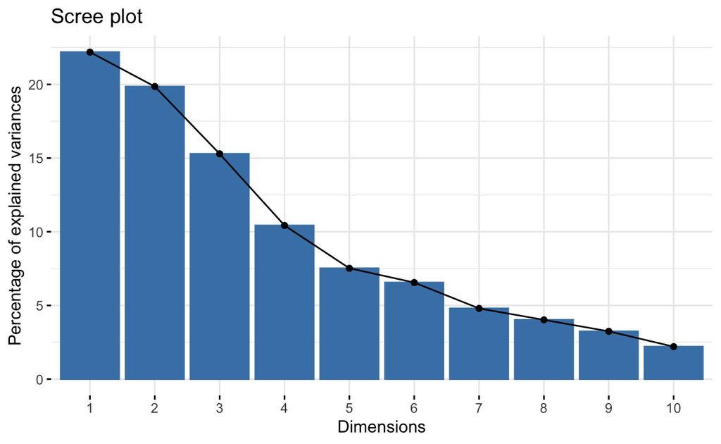

```r
# Visualize eigenvalues (scree plot). Show the percentage of variances explained by each principal component

fviz_eig(ncps.pca)
```

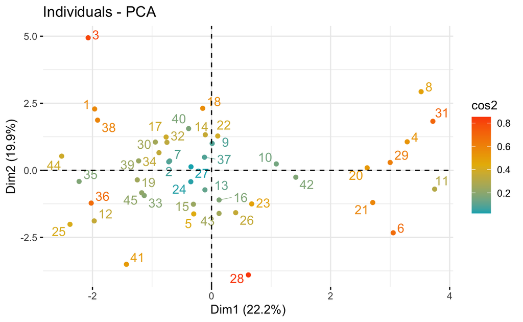

```r
# Graph of states States with a similar profile are grouped together

fviz_pca_ind(ncps.pca,
             col.ind = "cos2", # Color by the quality of representation
             gradient.cols = c("#00AFBB", "#E7B800", "#FC4E07"),
             repel = TRUE
             )
```

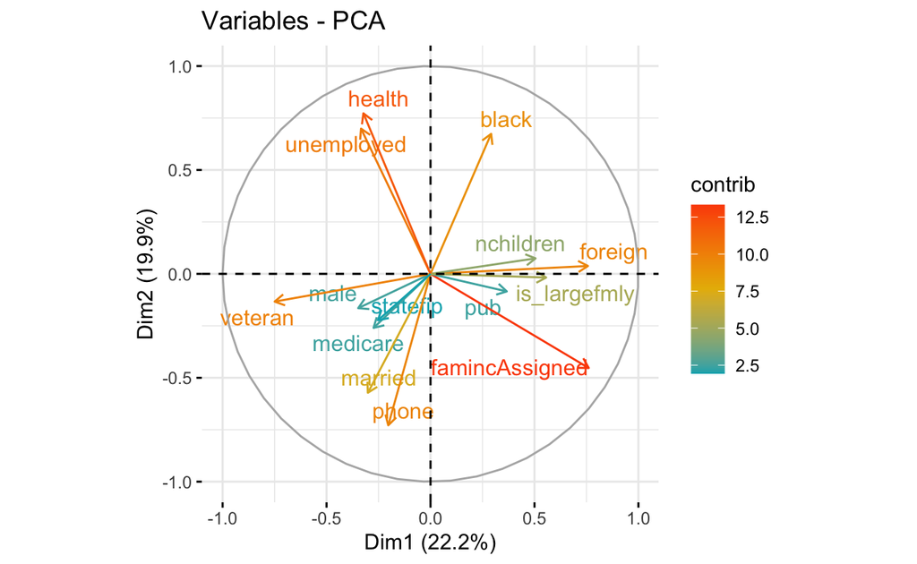

```r
# Graph of variables. Positive correlated variables point to the same side of the plot. Negative correlated variables point to opposite sides of the graph

fviz_pca_var(ncps.pca,
             col.var = "contrib", # Color by contributions to the PC
             gradient.cols = c("#00AFBB", "#E7B800", "#FC4E07"),
             repel = TRUE
             )
```

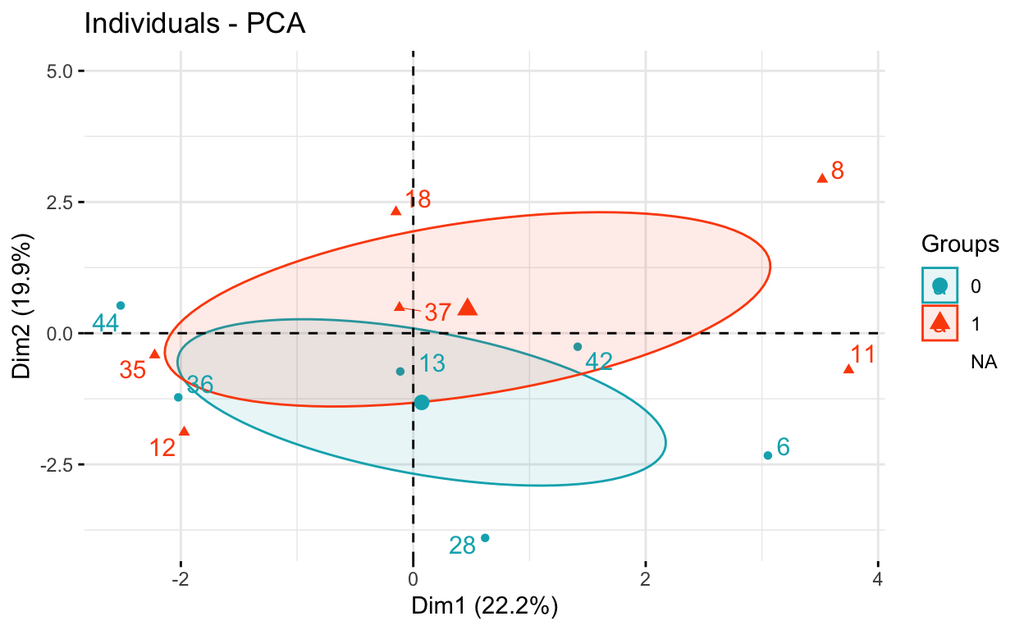

```r
groups <- as.factor(ncps_sub$pub[1:dim(ncps_statefip)[1]])

fviz_pca_ind(ncps.pca,
             col.ind = groups, # color by groups
             palette = c("#00AFBB",  "#FC4E07"),
             addEllipses = TRUE, # Concentration ellipses
             ellipse.type = "confidence",
             legend.title = "Groups",
             repel = TRUE
             )
```

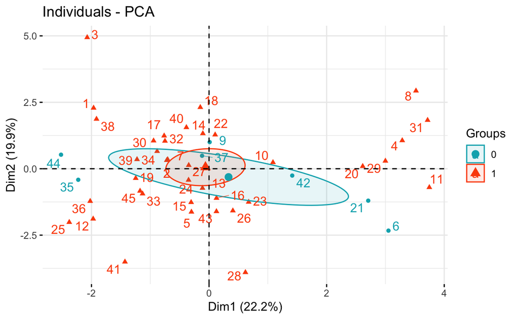

```r
groups <- as.factor(ncps_sub$medicare[1:dim(ncps_statefip)[1]])

fviz_pca_ind(ncps.pca,
             col.ind = groups, # color by groups
             palette = c("#00AFBB",  "#FC4E07"),
             addEllipses = TRUE, # Concentration ellipses
             ellipse.type = "confidence",
             legend.title = "Groups",
             repel = TRUE
             )
```